# NLP-Assignment-TAYSOKKEM

### Natural Language Processing Assignment

#### Course: TIPP Intake 1

#### Student Name: TAY SOK KEM

Note: by typing your full name, it is taken that you have read and understood the declaration below.

#### Declaration:

- I declare that this report is my original work. I understand that if I am suspected of plagiarism, my enrolment in the programme may be terminated.
- I declare that I have a back-up electronic copy of this report for immediate submission.

#### Overall design of this notebook:

1) Read from the csv file to a pandas dataframe  
2) Clean documents - WordNetLemmatizer, MWETokenizer  
3) Vectorize the clean corpus with extended list of stop_words -  
4) LDA - Perform topic modelling for the selected dataset and evaluate suitable topics classes (n_components)  
5) NMF - Perform topic modelling for the selected dataset and evaluate suitable topics classes (n_components)  
6) Final model visualization - model selected based on the optimal n_components from the evaluation  
7) Find dominant topics for LDA and most relevant document for NMF

#### Import all the necessary python modules & declare global variables

1) for text preprocessing  
2) for text vectorization and modeling  
3) for visualization

```python
import re, string, joblib
from datetime import datetime
from console_progressbar import ProgressBar
from tqdm import tqdm
import PySimpleGUI as sg
import pandas as pd
import numpy as np
import statistics as stats
import matplotlib.pyplot as plt
import seaborn as sns
from itertools import combinations
import gensim
from nltk.tokenize import MWETokenizer, word_tokenize
from nltk.corpus import wordnet
from nltk.tag import pos_tag
from nltk.stem import WordNetLemmatizer
from sklearn.feature_extraction.text import CountVectorizer, TfidfVectorizer
from sklearn.decomposition import LatentDirichletAllocation, NMF
import pyLDAvis
import pyLDAvis.sklearn

# please take note of files and directory
time = datetime.now().strftime("%Y-%m-%d")
#time ='2020-03-16'
pd.set_option('display.max_rows', 500)
csv_file = 'datasets/News Set A.csv'
sw_file = 'sci_reu.txt'
w2v_model_name = 'w2v-model-2020-03-12.bin'
min_comp = 25
max_comp = 32
no_top_words = 25
```

#### 1) Read from the csv file to a pandas dataframe

a) Numerical text and punctuation are removed

```python
def read_file(data_file):
    """ To read the data file to pandas dataframe """

    print("\nReading data from data file %s..." %(data_file))
    idx_col = 'id'

    df = pd.read_csv(data_file, index_col=idx_col)

    print("Column counts:\n", df.count())
    samples_counts = len(df.index)
    print("There are %i samples.\n" %samples_counts)

    #print("The first 5 records:\n", df.head(5))
    #print("The last 5 records:\n", df.iloc[-5:])

    print("Removing alphanumeric text, punctuations and make all 'contents' lower case...")
    alphanumeric = lambda x: re.sub(r"""\w*\d\w*""", ' ', x)
    punc_lower = lambda x: re.sub('[%s]' % re.escape(string.punctuation), '', x.lower())

    df['content'] = df.content.map(alphanumeric).map(punc_lower)

    list_contents = df['content'].to_list()
    print("Sample contents:", list_contents[0][0:500], list_contents[100][0:500])
    list_titles = df['title'].to_list()

    df1 = df['content']
    df1.to_csv('contents.csv')

    path1 = 'corpus-{}.pkl'.format(time)
    with open(path1, 'wb') as f1:
        joblib.dump(list_contents, f1)
    path2 = 'titles-{}.pkl'.format(time)
    with open(path2, 'wb') as f2:
        joblib.dump(list_titles, f2)

    print("File reading to dataframe completed.")

    return df, list_contents, list_titles

df_news, corpus, list_titles = read_file('datasets/News Set A.csv')
print("There are %i documents in the corpus." %(len(corpus)))
```

```
Reading data from data file datasets/News Set A.csv...
Column counts:
 Unnamed: 0     50000
title          50000
publication    50000
author         43694
date           50000
year           50000
month          50000
url                0
content        50000
dtype: int64
There are 50000 samples.

Removing alphanumeric text, punctuations and make all 'contents' lower case...
Sample contents: washington  —   congressional republicans have a new fear when it comes to their    health care lawsuit against the obama administration they might win the incoming trump administration could choose to no longer defend the executive branch against the suit which challenges the admin…
File reading to dataframe completed.
There are 50000 documents in the corpus.
```

#### 2) Clean the documents - WordNetLemmatizer, MWETokenizer

This is a recursive process with newly identified words for chunking (MWETokenizer).

a) Lemmatize documents - the Lemmatized words with Wordnet tags  
b) Compound word list is constructed based on the text modeling result

```python
def get_wordnet_pos(treebank_tag):
    #print("treebank_tag:", treebank_tag)

    if treebank_tag.startswith('J'):
        return wordnet.ADJ
    elif treebank_tag.startswith('V'):
        return wordnet.VERB
    elif treebank_tag.startswith('N'):
        return wordnet.NOUN
    elif treebank_tag.startswith('R'):
        return wordnet.ADV
    else:
        return ' '

def clean_documents(corpus):
    print("Documents cleaning in progress...")

    pb = ProgressBar(total=100,prefix='Cleaning documents...', suffix='Now', decimals=3, length=50, fill='X', zfill='-')
    #pb.print_progress_bar(0)

    cleaned_corpus = []
    corpus_len = len(corpus)
    for n, doc in zip(range(corpus_len), corpus):
        #lemmatize the document
        lem_tokens = (word_tokenize(doc))
        lem_tokens_pos = pos_tag(lem_tokens)
        #print("lem_tokens_pos:", lem_tokens_pos)
        lem_sentences = []
        for t in lem_tokens_pos:
            word = t[0]
            tag = get_wordnet_pos(t[1])
            if tag != ' ':
                lemmatiser = WordNetLemmatizer()
                lem_word = lemmatiser.lemmatize(word, tag)
                lem_sentences.append(lem_word)
            else:
                lem_sentences.append(word)
        lem_doc = " ". join(lem_sentences)

        #chunk the compound words
        mwe_tokenizer = MWETokenizer([('donald', 'trump'), ('donald', 'j', 'trump'),
                                      ('hillary', 'clinton'), ('state', 'secretary'),('mrs', 'clinton'),
                                      ('barack', 'obama'), ('george', 'w', 'bush'), ('white', 'house'),
                                      ('president', 'trump'), ('president', 'obama'), ('president', 'bush'),
                                      ('bush', 'administration'), ('obama', 'administration'), ('trump', 'administration'),
                                      ('vice', 'president'), ('security', 'adviser'), ('presidential', 'candidate'),
                                      ('bernie', 'sander'), ('ted', 'cruz'), ('james', 'comey'),
                                      ('united', 'state'), ('new', 'york'), ('new', 'york', 'city'),
                                      ('middle', 'east'), ('islamic', 'state'), ('prime', 'minister')],
                                      separator='_')
        mwe_doc = " ". join(mwe_tokenizer.tokenize(word_tokenize(lem_doc)))
        #print("Compound words tokens -> ", mwe_doc)

        cleaned_corpus.append(mwe_doc)

        p = (n+1) / corpus_len
        pb.print_progress_bar(p*100)
        #print("Document-%i cleaning completed." %(n))

    path = 'cleaned_corpus-{}.pkl'.format(time)
    with open(path, 'wb') as f:
        joblib.dump(cleaned_corpus, f)

    print("\n%i documents cleaning completed." %(n+1))

    return cleaned_corpus

#text = [' 2016', ' year2016', ' 2016year', ' year', ' years']
cleaned_corpus = clean_documents(corpus)
print("There are %i cleaned documents in the corpus." %(len(cleaned_corpus)))
```

```
Documents cleaning in progress...
Cleaning documents... |XXXXXXXXXXXXXXXXXXXXXXXXXXXXXXXXXXXXXXXXXXXXXXXXXX| 100.000% Now

50000 documents cleaning completed.
There are 50000 cleaned documents in the corpus.
```

```python
# path = 'cleaned_corpus-{}.pkl'.format(time)
# with open(path, 'rb') as f:
#     cleaned_corpus = joblib.load(f)

print("1:", cleaned_corpus[0])
print("2:", cleaned_corpus[10000])
print("3:", cleaned_corpus[-1])
```

```
1: washington — congressional republican have a new fear when it come to their health care lawsuit against the obama_administration they might win the incoming trump_administration could choose to no long defend the executive branch against the suit which challenge the administration ’ s authority t…
2: what originally seem an isolated group of small earthquake on new year ’ s eve have now grow to “ more than earthquake ” and apprehension be run high on january breitbart news report earthquake hit in the area of brawley ca abc report that the large of the quake be about magnitude they also repor…
3: the force of gravity can be describe use a number of metaphor it ’ s the glue that hold solar system and galaxy together the anchor that keep us on the ground the slingshot that send spacecraft deeper into the solar system and in some case gravity be a thief astronomer at the center for astrophys…
```

#### 3) Vectorize the clean corpus with extended list of stop_words

Note: The stop_words are extended recursively based on the result of text modeling

a) CountVectorizer  
b) TfidfVectorizer

```python
def read_sw(stop_words_file):
    print("Constructing stop_words...")
    df = pd.read_csv(stop_words_file, names=['word'])
    list_sw = df['word'].to_list()
    additional_sw = ['able', 'accord', 'breitbart', 'ad', 'ask', 'called', 'cnn', 'com', 'day', 'country',
                     'did', 'didn', 'doesn', 'don', 'fox', 'hi', 'include', 'like', 'll', 'month', 'mr', 'ms',
                     'news', 'people', 'president', 've', 'wa', 'want', 'week', 'wouldn', 'say', 'said', 'state',
                     'tell', 'time', 'thi', 'trump', 'yes', 'year', 'years']
    list_sw.extend(additional_sw)

    print("stop_words construction completed.")

    return list_sw

list_sw = read_sw('sci_reu.txt')
print("List of extended stop words:", list_sw)
```

```
Constructing stop_words...
stop_words construction completed.
List of extended stop words: ['a', 'about', 'above', 'according', 'across', 'actual', 'added', 'after', 'afterwards', 'again', 'against', 'ahead', 'all', 'almost', 'alone', 'along', 'already', 'also', 'although', 'always', 'am', 'among', 'amongst', 'amoungst', 'amount', 'an', 'and', 'and-or', 'and/o…
```

```python
def perform_cv(sw, corpus, no_features=1000):
    print("Performing CountVectorizer with %i features..." %no_features)

    cv = CountVectorizer(max_features=no_features, analyzer='word', stop_words=sw)
    doc_terms_matrix = cv.fit_transform(corpus)
    cv_feature_names = cv.get_feature_names()
    df_dtm = pd.DataFrame(doc_terms_matrix.toarray(), columns=cv_feature_names)
    print(df_dtm)

    path = 'countvectoriser-{}.pkl'.format(time)
    with open(path, 'wb') as f:
        joblib.dump(cv, f)

    return cv, doc_terms_matrix, cv_feature_names

cv, cv_doc_terms_matrix, cv_tf_feature_names = perform_cv(list_sw, cleaned_corpus)
```

```
Performing CountVectorizer with 1000 features...
       ability  abortion  abuse  accept  access  account  accuse  acknowledge  \
0            0         0      0       0       1        0       0            1
1            1         0      0       0       1        0       0            1
2            0         0      0       0       0        1       0            0
3            0         0      0       0       0        0       0            0
4            1         0      0       0       0        0       0            0
...        ...       ...    ...     ...     ...      ...     ...          ...
49995        1         0      0       0       0        0       0            0
49996        0         0      0       0       0        0       0            0
49997        3         0      1       2       1        1       2            2
49998        0         0      0       0       6        0       0            2
49999        0         0      0       0       0        0       0            0

       act  action  ...  woman  word  work  worker  world  worry  worth  \
```

[output cut: 26 more lines]

```python
def perform_tfidf(sw, corpus, no_features=1000):
    print("Perform TfidfVectorizer with %i features..." %no_features)

    tfidf = TfidfVectorizer(max_features=no_features, stop_words=sw)
    doc_terms_matrix = tfidf.fit_transform(corpus)
    tf_feature_names = tfidf.get_feature_names()
    print("doc_terms_matrix: ", doc_terms_matrix)
    print("tf_feature_names", tf_feature_names)
#     df_dtm = pd.DataFrame(doc_terms_matrix.toarray(), columns=tf_feature_names)
#     print(df_dtm)

    path = 'tfidfvectorizer-{}.pkl'.format(time)
    with open(path, 'wb') as f:
        joblib.dump(tfidf, f)

    return tfidf, doc_terms_matrix, tf_feature_names

tfidf, tfidf_doc_terms_matrix, tfidf_tf_feature_names = perform_tfidf(list_sw, cleaned_corpus)
```

[output not shown]

#### 4) LDA - Perform topic modelling for the selected dataset and evaluate suitable topics classes

a) text modeling with CV  
b) tuning parameter 'n_components' to get log_likelihood and perplexity scores for model selection

- The lowest Perplexity
- The highest Log-Likelihood

c) plotting log_likelihood and perplexity scores to get the best n_components

```python
def perform_LDA(doc_terms_matrix, comp_min, comp_max, vec_type):
    prefix = 'Performing LDA on {} with {} to {} components...'.format(vec_type, comp_min, comp_max)
    pb = ProgressBar(total=100,prefix=prefix, suffix='Now', decimals=3, length=50, fill='X', zfill='-')
    pb.print_progress_bar(0)

    lda_models = []
    for n in range(comp_min, comp_max+1):
        #print("Applying LDA for n=%i ..." %n )
        lda_model = LatentDirichletAllocation(n_components=n, max_iter=5, learning_method='online', learning_offset=50., random_state=23)
        doc_topic_matrix = lda_model.fit_transform(doc_terms_matrix)

        log_likelihood = lda_model.score(doc_terms_matrix)
        perplexity = lda_model.perplexity(doc_terms_matrix)
        #print("Components:", lda_model.components_)
        lda_models.append((n, lda_model, doc_topic_matrix, log_likelihood, perplexity)) # store for later

        #print(doc_topic_matrix.shape)  #the weights/probalities of each topics for each of the documents, total of 1
        #print(doc_topic_matrix)
        p = (n - comp_min + 1) / (comp_max - comp_min + 1)
        pb.print_progress_bar(p*100)

    path = '{}_lda_models-{}.pkl'.format(vec_type, time)
    with open(path, 'wb') as f:
        joblib.dump(lda_models, f)

    return lda_models

cv_lda_models = perform_LDA(cv_doc_terms_matrix, min_comp, max_comp, 'cv')
```

```
Performing LDA on cv with 25 to 32 components... |XXXXXXXXXXXXXXXXXXXXXXXXXXXXXXXXXXXXXXXXXXXXXXXXXX| 100.000% Now
```

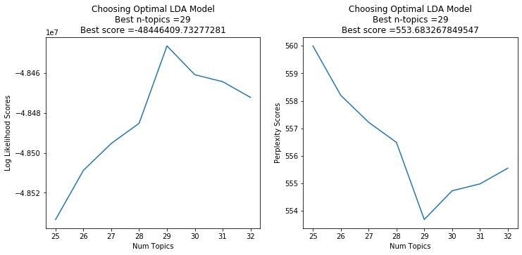

```python
def plot_lda_scores(lda_models, s_label, s_idx, sh, lo):
    ax = plt.subplot2grid(sh, lo)
    n_comp = range(lda_models[0][0], lda_models[-1][0]+1)
    list_scores = [lda_models[i][s_idx] for i in range(len(lda_models))]
    ax.set_xlabel('Num Topics')
    ax.set_ylabel(s_label + ' Scores')
    plt.plot(n_comp, list_scores)
    if s_label == 'Log Likelihood':
        best_score = max(list_scores)
    elif s_label == 'Perplexity':
        best_score = min(list_scores)
    best_model_idx = list_scores.index(best_score)
    best_n_comp = lda_models[best_model_idx][0]
    ax.set_title('Choosing Optimal LDA Model' + '\nBest n-topics =' + str(best_n_comp)+ '\nBest score =' + str(best_score))

    return best_n_comp

fig, axes = plt.subplots(1, 2, figsize=(12, 5))
plt.rcParams.update({'font.size': 10})
lda_best_n_comp = plot_lda_scores(cv_lda_models, 'Log Likelihood', 3, (1,2),(0,0))
lda_best_n_comp = plot_lda_scores(cv_lda_models, 'Perplexity', 4, (1,2),(0,1))
plt.show()
```

#### 5) NMF - Perform topic modelling for the selected dataset and evaluate suitable topics classes

a) text modeling with TF-IDF  
b) tuning parameter 'n_components' to get coherence scores for model selection  
c) plotting coherence scores to get the best n_components

```python
def perform_NMF(doc_terms_matrix, comp_min, comp_max, vec_type):
    prefix = 'Performing NMF on {} with {} to {} components...'.format(vec_type, comp_min, comp_max)
    pb = ProgressBar(total=100,prefix=prefix, suffix='Now', decimals=3, length=50, fill='X', zfill='-')
    pb.print_progress_bar(0)

    nmf_models = []
    for n in range(comp_min, comp_max+1):
        nmf_model = NMF(n_components=n, init='random', random_state=23)
        A = doc_terms_matrix
        W_doc_topic_matrix = nmf_model.fit_transform(A)
        H_topic_terms_matrix = nmf_model.components_
        #print(W_doc_topic_matrix.shape, W_doc_topic_matrix)
        #print(H_topic_terms_matrix.shape, H_topic_terms_matrix)
        nmf_models.append((n, nmf_model, W_doc_topic_matrix, H_topic_terms_matrix)) # store for later

        p = (n - comp_min + 1) / (comp_max - comp_min + 1)
        pb.print_progress_bar(p*100)

    path = '{}_nmf_models-{}.pkl'.format(vec_type, time)
    with open(path, 'wb') as f:
        joblib.dump(nmf_models, f)

    return nmf_models

tfidf_nmf_models = perform_NMF(tfidf_doc_terms_matrix, min_comp, max_comp, 'tfidf')
```

```
Performing NMF on tfidf with 25 to 32 components... |XXXXXXXXXXXXXXXXXXXXXXXXXXXXXXXXXXXXXXXXXXXXXXXXXX| 100.000% Now
```

```
K=25: Coherence=0.2882
K=26: Coherence=0.2899
K=27: Coherence=0.2830
K=28: Coherence=0.2791
K=29: Coherence=0.2771
K=30: Coherence=0.2776
K=31: Coherence=0.2768
K=32: Coherence=0.2760
```

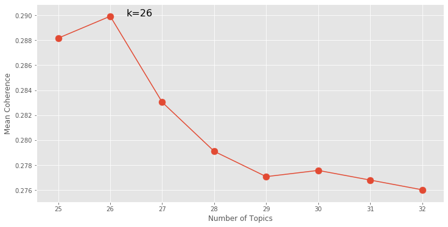

```python
# select optimal parameter for NMF based on coherence scores
# codes from LU06 - Ex6
def calculate_coherence(w2v_model, term_rankings):
    overall_coherence = 0.0
    for topic_index in range(len(term_rankings)):
        # check each pair of terms
        pair_scores = []
        for pair in combinations(term_rankings[topic_index], 2):
            pair_scores.append(w2v_model.wv.similarity(pair[0], pair[1]))
        # get the mean for all pairs in this topic
        topic_score = sum(pair_scores) / len(pair_scores)
        overall_coherence += topic_score
    # get the mean score across all topics
    return overall_coherence / len(term_rankings)

def get_descriptor(terms, H, topic_index, top):
    # reverse sort the values to sort the indices
    top_indices = np.argsort(H[topic_index,:])[::-1]
    # now get the terms corresponding to the top-ranked indices
    top_terms = []
    for term_index in top_indices[0:top]:
        top_terms.append(terms[term_index])
    return top_terms

def compute_coherence_scores(topic_models, terms):
    w2v_model = gensim.models.Word2Vec.load(w2v_model_name)

    k_values = []
    coherences = []
    min_comp = 25
    max_comp = 32
    for (k,m,W,H) in topic_models:
        # Get all of the topic descriptors - the term_rankings, based on top 10 terms
        term_rankings = []
        for topic_index in range(k):
            term_rankings.append(get_descriptor(terms, H, topic_index, 10))
        # Now calculate the coherence based on our Word2vec model
        k_values.append(k)
        coherences.append(calculate_coherence(w2v_model, term_rankings))
        print("K=%02d: Coherence=%.4f" % (k, coherences[-1]))

    path = 'kvalcohe-{}.pkl'.format(time)
    with open(path, 'wb') as f:
        joblib.dump((k_values, coherences), f)

    return k_values, coherences

def plot_nmf_coherence(k_values, coherences):
    plt.figure(figsize=(12, 6))
    plt.rcParams.update({'font.size': 14})
    plt.style.use("ggplot")
    # create the line plot
    plt.plot(k_values, coherences)
    plt.xticks(k_values)
    plt.xlabel("Number of Topics")
    plt.ylabel("Mean Coherence")
    # add the points
    plt.scatter(k_values, coherences, s=120)
    # find and annotate the maximum point on the plot
    ymax = max(coherences)
    xpos = coherences.index(ymax)
    best_k = k_values[xpos]
    plt.annotate( "k=%d" % best_k, xy=(best_k, ymax), xytext=(best_k, ymax), textcoords="offset points", fontsize=16)
    # show the plot
    plt.show()

    return best_k

k_values, coherences = compute_coherence_scores(tfidf_nmf_models, tfidf.get_feature_names())
nmf_best_n_comp = plot_nmf_coherence(k_values, coherences)
```

#### 6) Final model visualization - model selected based on the optimal n_components from the evaluation

1) LDA - pyLDAvis  
2) NMF - Bar chart

```python
# apply LDA with the best n_components and display the topics
def display_topics(model, feature_names, no_top_words):
    for topic_idx, topic in enumerate(model.components_):
        print ("Topic %d:" % (topic_idx))
        print (" ".join([feature_names[i]
                         for i in topic.argsort()[:-no_top_words - 1:-1]]))

def apply_LDA(doc_terms_matrix, n_comp):
    print("Applying LDA for %i components..." %n_comp)
    lda_model = LatentDirichletAllocation(n_components=n_comp, max_iter=5, learning_method='online', learning_offset=50. ,random_state=23)
    doc_topic_matrix = lda_model.fit_transform(doc_terms_matrix)

    log_likelihood = lda_model.score(doc_terms_matrix)
    perplexity = lda_model.perplexity(doc_terms_matrix)
    #print("Components:", lda_model.components_)

    print(doc_topic_matrix.shape)  #the weights/probalities of each topics for each of the documents, total of 1
    #print(doc_topic_matrix)

    path = 'selected-lda_model-{}.pkl'.format(time)
    with open(path, 'wb') as f:
        joblib.dump(lda_model, f)

    return lda_model, doc_topic_matrix

cv_lda_model, cv_doc_topic_matrix = apply_LDA(cv_doc_terms_matrix, lda_best_n_comp)
display_topics(cv_lda_model, cv.get_feature_names(), no_top_words)
pyLDAvis.enable_notebook()
panel = pyLDAvis.sklearn.prepare(cv_lda_model, cv_doc_terms_matrix, cv)
panel
```

```
Applying LDA for 29 components...
(50000, 29)
Topic 0:
china trade chinese deal agreement united_state world international island foreign economic government global sea free policy south economy relation region relationship official issue military american
Topic 1:
report official statement source member office meeting letter work chief staff document release comment team interview committee organization question request investigation director public write executive
Topic 2:
city area home flight local resident hour building plane park new travel airport official town county saturday new_york street leave mile place night fly car
Topic 3:
think know thing good work lot need talk right happen try mean question feel point bad kind start big believe great actually idea fact different
Topic 4:
black white protest march protester event group rally matter speech right movement flag america milo life crowd woman stand activist king american supporter race community
Topic 5:
police officer gun kill arrest report man shoot suspect victim incident attack authority charge crime shooting video murder death law enforcement car investigation assault violence
Topic 6:
medium post twitter facebook video social write tweet follow story page photo claim report article online account user publish site read editor comment website journalist
Topic 7:
percent rate job worker number increase american high report economy low economic growth rise average million labor data likely population new point level total policy
Topic 8:
game team win play player sport season second world final point fan club lead run field race end open start set round sunday minute record
Topic 9:
muslim right law ban christian religious community islam gay group church islamic american freedom government attack support amendment human protect issue citizen society political act
Topic 10:
refugee iran israel saudi united_state deal peace united nation security world international syrian order syria council government agreement foreign support nuclear talk live eastern program
Topic 11:
use apple service google information data security technology new company phone internet user email work search access test program secret provide agency tech online allow
Topic 12:
immigration border texas immigrant mexico illegal california mexican wall agent los enforcement san ice report angeles law criminal drug united_state city official county security federal
Topic 13:
school student university college education campus professor high class public program community parent common child district free kid write standard attend group board california young
Topic 14:
russia russian fbi intelligence investigation comey official putin committee election flynn director information report white_house session campaign national government agency general evidence foreign israeli security
Topic 15:
republican house ryan senate care health democrat congress plan obamacare vote paul speaker repeal pass law act leader senator member legislation insurance conservative american congressional
Topic 16:
north south korea carolina nuclear missile korean test weapon launch defense military official use program threat united_state park strike security leader new statement force ally
Topic 17:
company business market price car ceo sell insider sale new product industry billion stock buy store investor customer model share million big employee brand firm
Topic 18:
clinton campaign hillary_clinton twitter email donald_trump pic hillary presidential debate follow democratic nominee july press secretary question release june http attack speech tweet comment know
Topic 19:
change water climate world new use project space energy human oil work design food power research global science create need lead level help build large
Topic 20:
woman health drug men medical sexual case patient disease abortion doctor sex female hospital treatment care use report risk child body treat cause center test
Topic 21:
family child life father mother son home young friend parent girl know daughter death work die live wife help boy brother leave love man woman
Topic 22:
film star movie play music new actor series tv art character book night love work television watch role write brown feature story performance release audience
Topic 23:
republican vote voter campaign party election win candidate poll donald_trump sen cruz support democratic democrat rubio nominee presidential sander gop primary convention race conservative run
Topic 24:
attack isi military force group syria kill terrorist war iraq government security fight bomb official syrian islamic_state al terror turkey civilian fighter army soldier strike
Topic 25:
obama american white_house policy america washington donald_trump administration united_state penny national political barack_obama campaign secretary speech foreign leader nation office new president_obama great issue world
Topic 26:
european party europe migrant london union britain french france leave germany british vote government german leader prime_minister political election remain paris minister world new member
Topic 27:
million tax money pay fund government bank billion financial foundation dollar federal business plan cost cut program raise budget wall return street spend benefit help
Topic 28:
court case justice judge law attorney federal supreme order legal prison charge lawyer sentence rule prosecutor decision trial lawsuit right file general district criminal appeal
```

[interactive chart not shown]

```
Applying NMF for 26 components...
W: (50000, 26)
H: (26, 1000)
```

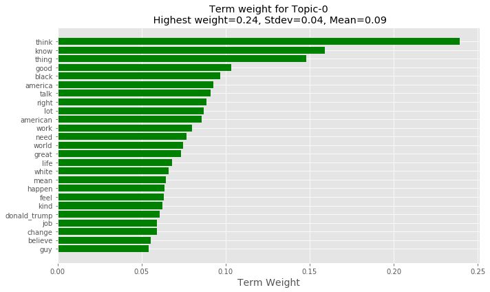

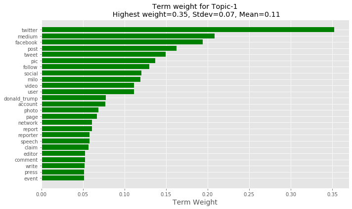

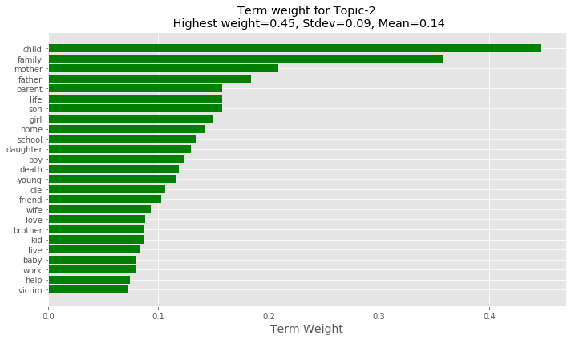

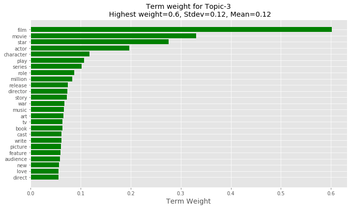

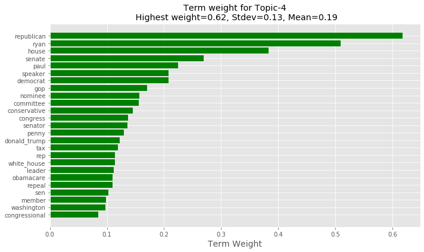

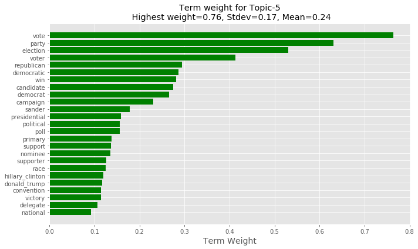

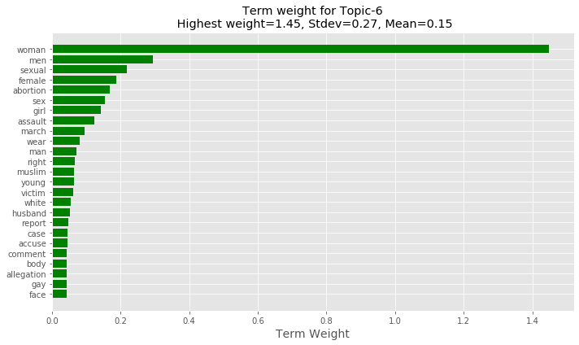

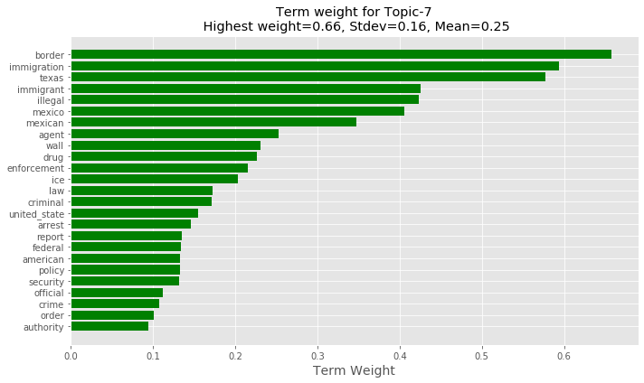

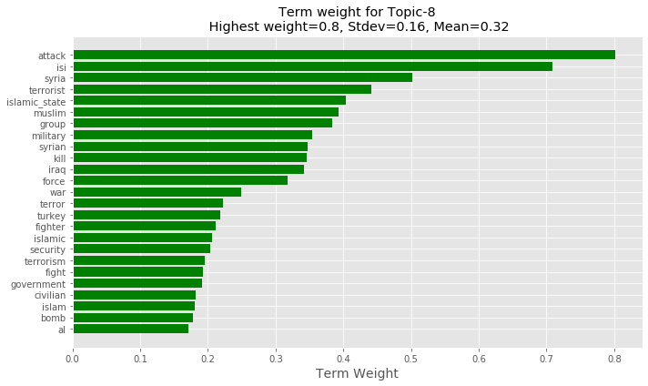

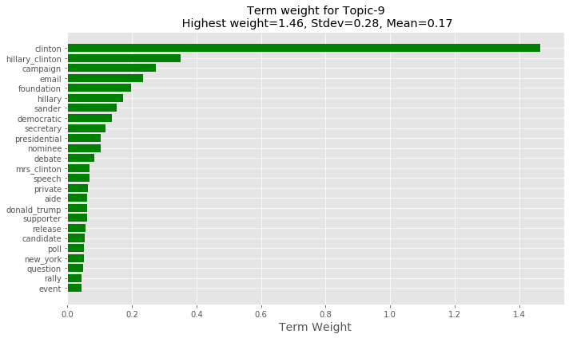

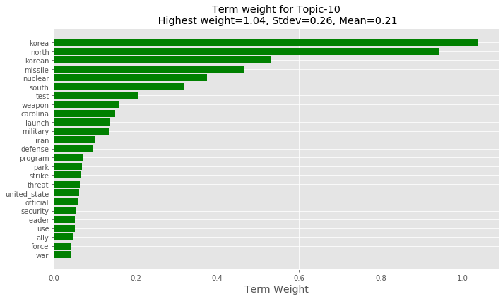

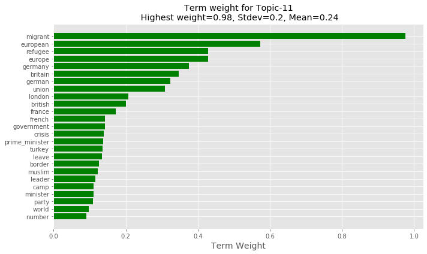

[14 more figures not shown]

```python
# apply NMF with the best n_components and display the topics
def apply_NMF(tfidf_doc_terms_matrix, n_comp):
    print("Applying NMF for %i components..." %n_comp)

    nmf_model = NMF(n_components=n_comp, init='random', random_state=23)
    A = tfidf_doc_terms_matrix
    W_doc_topic_matrix = nmf_model.fit_transform(A)
    H_topic_terms_matrix = nmf_model.components_
    #print(W_doc_topic_matrix.shape, W_doc_topic_matrix)
    #print(H_topic_terms_matrix.shape, H_topic_terms_matrix)
    print("W:", W_doc_topic_matrix.shape)
    print("H:", H_topic_terms_matrix.shape)

    path = 'selected-nmf_model-{}.pkl'.format(time)
    with open(path, 'wb') as f:
        joblib.dump((nmf_model, H_topic_terms_matrix) , f)

    return nmf_model, W_doc_topic_matrix, H_topic_terms_matrix

# explore NMF topic-terms distribution
# codes modified from LU06- Ex4
def plot_nmf_term_weights(terms, H, topic_index, top):
    #get the top terms and their weights

    top_indices = np.argsort(H[topic_index,:])[::-1]
    top_terms = []
    top_weights = []
    for term_index in top_indices[0:top]:
        top_terms.append(terms[term_index])
        top_weights.append(H[topic_index, term_index])
    #note we reverse the ordering for the plot
    top_terms.reverse()
    top_weights.reverse()
    #create the plot
    plt.figure(figsize=(10,6))
    #add the horizontal bar chart
    ypos = np.arange(top)
    highest_weight = max(top_weights)
    lowest_weight = min(top_weights)
    mean_weight = stats.mean(top_weights)
    stdev_weight = stats.pstdev(top_weights)
    title = 'Term weight for Topic-{}\n Highest weight={}, Stdev={}, Mean={}'.format(topic_index, round(highest_weight,2), round(stdev_weight,2), round(mean_weight,2))
    plt.title(title)
    plt.barh(ypos, top_weights, align="center", color="green",tick_label=top_terms)
    plt.xlabel("Term Weight",fontsize=14)
    plt.tight_layout()
    #plt.show()

tfidf_nmf_model, W, H = apply_NMF(tfidf_doc_terms_matrix, nmf_best_n_comp)
# path = 'selected-nmf_model-{}.pkl'.format(time)
# with open(path, 'rb') as f:
#     tfidf_nmf_model, H = joblib.load(f)

tfidf_feature_names = tfidf.get_feature_names()

for n in range(nmf_best_n_comp):
    plot_nmf_term_weights(tfidf_feature_names, H, n, no_top_words)
    plt.show()
```

#### 7) Find dominant topics

a) LDA - find dominant topics

b) NMF - find most relevant documents

- get the top 10 document for each topics by entering selection in the pop-up window

```python
# LDA - Find dominant topics
# codes modified from LU05 - Ex3
def display_dom_topic(lda_model, documents, cv_doc_topic_matrix, dom_score, cond):
    """ To display the dominant topicand scores for documents """

    print("Displaying the dominant topic and scores for documents...")
    #column names
    topicnames = ["Topic" + str(i) for i in range(lda_model.n_components)]

    #index names
    docnames = ["Doc-" + str(i) for i in range(len(documents))]

    #make the pandas dataframe
    list_doc_scores = np.round(cv_doc_topic_matrix, 2)
    # Get dominant topic for each document
    ttl_docs = len(documents)
    dominant_topic = [np.argmax(list_doc_scores[j]) for j in tqdm(range(ttl_docs))]
    df_document_topic = pd.DataFrame(index=docnames)
    df_document_topic['dominant_topic'] = dominant_topic
    df_document_topic['dominant_score'] = [list_doc_scores[i][dominant_topic[i]] for i in tqdm(range(len(dominant_topic)))]

    # print the dataframe with dominant scores
    #df_document_topic2 = df_document_topic.head(no_docs).style.applymap(color_green).applymap(make_bold)
    #df_document_topic2 = df_document_topic.head(no_docs)
    if cond == 'lt':
        df_document_topic2 = df_document_topic[df_document_topic['dominant_score'] < dom_score]
        cond_stat = 'less than'
    elif cond == 'ge':
        df_document_topic2 = df_document_topic[df_document_topic['dominant_score'] >= dom_score]
        cond_stat = 'greater or equal to'
    print("There are %i documents, %i unique topics with dominant score %s %.2f." %(len(df_document_topic2), len(df_document_topic2['dominant_topic'].unique()), cond_stat, dom_score))
    print(df_document_topic2)
    print("Document counts with dominant scores more than %.2f, per topic: \n%s" %(dom_score, df_document_topic2['dominant_topic'].value_counts()))

    return df_document_topic2

print("Finding dominant topics...")
dom_score = 0.8
df_document_topic = display_dom_topic(cv_lda_model, cleaned_corpus, cv_doc_topic_matrix, dom_score, 'ge')
```

```
Finding dominant topics...
Displaying the dominant topic and scores for documents...
There are 1356 documents, 29 unique topics with dominant score greater or equal to 0.80.
           dominant_topic  dominant_score
Doc-4                  16            0.84
Doc-147                 8            0.91
Doc-167                22            0.95
Doc-173                16            0.89
Doc-196                 8            0.91
...                   ...             ...
Doc-49760               8            0.95
Doc-49902              22            0.90
Doc-49936              19            0.80
Doc-49944              19            0.84
Doc-49966              15            0.89

[1356 rows x 2 columns]
Document counts with dominant scores more than 0.80, per topic:
8     238
23    213
5     132
17    106
15     96
14     82
24     79
22     78
2      54
18     46
26     44
19     33
16     30
7      21
3      19
6      15
28     15
12     12
25     11
11      7
20      5
21      5
1       5
10      4
27      2
9       1
13      1
4       1
0       1
Name: dominant_topic, dtype: int64
```

```python
# LDA - based on the dominant topics and scores, validate the accuracy
def display_topic_terms(model, feature_names, no_top_words, topic_idx):
    topic = model.components_[topic_idx]
    topic_terms = " ".join([feature_names[i]
                         for i in topic.argsort()[:-no_top_words - 1:-1]])

    print ("Topic-%d:" % (topic_idx))
    print (" ".join([feature_names[i]
                     for i in topic.argsort()[:-no_top_words - 1:-1]]))

print("Please input your option in the pop up window...")
layout = [[sg.Text('Please input:')],
          [sg.Text('Topic index:', size=(30, 1)), sg.InputText()],
          [sg.Text('Number of Terms for the topic:', size=(30, 1)), sg.InputText()],
          [sg.Text('Number of Documents for the topic:', size=(30, 1)), sg.InputText()],
          [sg.Submit(), sg.Cancel()]]

window = sg.Window('LDA- Documents with the same dominant topic', layout)
event, values = window.read()
window.close()

#get the data from the values dictionary
topic_idx, no_terms, no_docs = \
    int(values[0]), int(values[1]), int(values[2])

display_topic_terms(cv_lda_model, cv.get_feature_names(), no_terms, topic_idx)
doc_dom_topic = df_document_topic[df_document_topic['dominant_topic'] == topic_idx].index

print(doc_dom_topic)
for i in range(len(doc_dom_topic)):
    if i < no_docs:
        doc_idx = int(doc_dom_topic[i].split('-')[1])
        print("Document-%i: \nTitle-'%s' \nSnippets-'%s'" %(doc_idx, list_titles[doc_idx], cleaned_corpus[doc_idx][0:150]))
```

```
Please input your option in the pop up window...
Topic-16:
north south korea carolina nuclear missile korean test weapon launch defense military official use program threat united_state park strike security
Index(['Doc-4', 'Doc-173', 'Doc-1062', 'Doc-1557', 'Doc-1924', 'Doc-3916',
       'Doc-6095', 'Doc-9733', 'Doc-25404', 'Doc-28141', 'Doc-32591',
       'Doc-33123', 'Doc-33133', 'Doc-33453', 'Doc-33732', 'Doc-34403',
       'Doc-34827', 'Doc-34883', 'Doc-35039', 'Doc-35255', 'Doc-37180',
       'Doc-37190', 'Doc-38434', 'Doc-38497', 'Doc-43648', 'Doc-43884',
       'Doc-43911', 'Doc-44769', 'Doc-44785', 'Doc-44869'],
      dtype='object')
Document-4:
Title-'Kim Jong-un Says North Korea Is Preparing to Test Long-Range Missile - The New York Times'
Snippets-'seoul south korea — north korea ’ s leader kim say on sunday that his country be make final preparation to conduct its first test of an intercontinent'
Document-173:
Title-'North Korea, Rebuking Trump, Says It Can Test Long-Range Missile ‘Anytime’ - The New York Times'
Snippets-'seoul south korea — less than a week after donald_j_trump taunt north korea over its ballistic missile capability north korea have say that it could c'
Document-1062:
Title-'North Korea Fires Ballistic Missile, Challenging Trump - The New York Times'
Snippets-'seoul south korea — north korea launch a ballistic missile toward the sea off its eastern coast on sunday in what south korea call the north ’ s first'
Document-1557:
Title-'North Korea’s Launch of Ballistic Missiles Raises New Worries - The New York Times'
Snippets-'seoul south korea — north korea launch four ballistic missile from its rocket launch site on monday morning the south korean military say the launch p'
Document-1924:
Title-'North Korea’s Test of Rocket Engine Shows ‘Meaningful Progress,’ South Says - The New York Times'
Snippets-'seoul south korea — north korea ’ s late test of a rocket engine show that the country be make “ meaningful progress ” in try to build more powerful r'
Document-3916:
Title-'North Korea’s Nuclear Blasts Keep Getting Stronger - The New York Times'
Snippets-'north korea say it conduct its fifth underground nuclear test on friday since the first test almost a decade ago the size of the result earthquake fro'
Document-6095:
Title-'New Test of North Korean Missile Fails, South Says - The New York Times'
Snippets-'seoul south korea — north korea launch an ballistic missile but the test fail as the projectile explode shortly after liftoff the south korean militar'
Document-9733:
Title-'North Korean Missile Explodes Seconds After Launch'
Snippets-'the late north korean missile test fail on wednesday with the rocket explode “ within second of launch ” accord to the u s pacific command “ south kor'
Document-25404:
Title-'North Korean Ballistic Missile Launch Fails'
Snippets-'american and south korean military official be report that north korea ’ s late missile test time to coincide with the birthday of “ eternal president'
Document-28141:
Title-'North Korea Test Fires Two Mid-range Ballistic Missiles - Breitbart'
Snippets-'seoul afp — north korea test fire what appear to be two ballistic missile on friday just day after leader kim promise a series of nuclear warhead test'
```

[output cut: 15 more lines]

```
Document-34403:
Title-'US Air Force tests another long-range missile'
Snippets-'washington cnn the air force on wednesday launch its second test of a missile in a week accord to the air force global strike command launch from vand'
Document-34827:
Title-'North Korea fires another ballistic missile'
Snippets-'cnn north korea conduct its second missile test within a week send a ballistic missile into the water off its east coast sunday accord to statement fr'
Document-34883:
Title-'Unidentified objects flies from North Korea over border with South'
Snippets-'seoul south korea cnn unidentified object which fly across the border from the north be probably propaganda balloon south korea ’ s military say wedne'
Document-35039:
Title-'Missile test showed highly accurate warhead, says North Korea'
Snippets-'cnn north korea claim it fire a new type of ballistic missile monday demonstrate its ability to carry out a highly accurate strike expert however have'
Document-35255:
Title-'North Korea launches 4 anti-ship missiles, fourth test in a month'
Snippets-'cnn north korea fire four missile into the sea east of the korean peninsula thursday which the south korean military say be intend to demonstrate its '
```

```python
### NMF - find most relevant document for NMF
# codes modified from LU06 - Ex5
def get_top_snippets(all_snippets, W, topic_index, top):
    # reverse sort the values to sort the indices
    top_indices = np.argsort(W[:,topic_index] )[::-1]
    # now get the snippets corresponding to the top-ranked indices
    top_snippets, top_scores = [], []
    for doc_index in top_indices[0:top]:
        top_scores.append(W[doc_index][topic_index])
        top_snippets.append(all_snippets[doc_index])
    return top_snippets, top_scores

def display_rel_docs(snippets, W, top_idx, no_docs):
    """ To display relevant documents for a topic """

    print("Titles of Top-%i relevant documents for Topic-%i with document scores..." %(no_docs, top_idx))

    #print("All doc-top:", W.shape)

    topic_snippets, top_scores = get_top_snippets(snippets, W, top_idx, no_docs) #topic-0, top-10 documents

    for i, snippet in enumerate(topic_snippets):
        print("%02d. %s (score: %.2f)" % ((i+1), snippet, top_scores[i]))

print("Finding relevant documents...Please input your option in the pop up window...")
layout = [[sg.Text('Please input:')],
          [sg.Text('Topic index:', size=(30, 1)), sg.InputText()],
          [sg.Text('Number of Terms for the topic:', size=(30, 1)), sg.InputText()],
          [sg.Text('Number of Documents for the topic:', size=(30, 1)), sg.InputText()],
          [sg.Submit(), sg.Cancel()]]

window = sg.Window('NMF - Relevant documents to the topic', layout)
event, values = window.read()
window.close()

#get the data from the values dictionary
top_idx, no_terms, no_docs = \
    int(values[0]), int(values[1]), int(values[2])

tfidf_feature_names = tfidf.get_feature_names()
topic_terms = get_descriptor(tfidf_feature_names, H, top_idx, no_terms)
print("Top-%i terms for Topic-%i: %s" %(no_terms, top_idx, topic_terms))
display_rel_docs(list_titles, W, top_idx, no_docs)
```

```
Finding relevant documents...Please input your option in the pop up window...
Top-20 terms for Topic-8: ['attack', 'isi', 'syria', 'terrorist', 'islamic_state', 'muslim', 'group', 'military', 'syrian', 'kill', 'iraq', 'force', 'war', 'terror', 'turkey', 'fighter', 'islamic', 'security', 'terrorism', 'fight']
Titles of Top-20 relevant documents for Topic-8 with document scores...
01. ISIS’ Ramadan terror campaign (score: 0.36)
02. The unlikely godfather of the Islamic State (score: 0.35)
03. Death of senior leader caps bad month for ISIS (score: 0.34)
04. ISIS Fast Facts (score: 0.34)
05. Why ISIS is winning, and how its foes can reverse it (score: 0.34)
06. Key ISIS deputy and spokesman killed in Syria (score: 0.33)
07. ’He chose the perfect time to cause casualties’: At least 140 killed in central Baghdad suicide bombing (score: 0.33)
08. The Ten Major Military Players Fighting for the Heart of Syria - Breitbart (score: 0.33)
09. Spate of terror attacks as Ramadan draws to a close (score: 0.33)
10. ISIS claims Baghdad bombing 200 dead (score: 0.33)
11. ISIS claims credit for Baghdad blast that kills 7 (score: 0.33)
12. Video Surfaces of U.S. Presence Near Turkish Soldiers, Kurdish Militia on Syrian Border - Breitbart (score: 0.33)
13. Terror attacks: What they say about ISIS (Opinion) (score: 0.33)
14. 9/11: Bin Laden’s spectacular miscalculation (score: 0.32)
15. ISIS: 143 attacks in 29 countries have killed 2,043 (score: 0.32)
16. US doubts Russia’s claim it killed ISIS spokesman (score: 0.32)
17. Senior ISIS Strategist and Spokesman Is Reported Killed in Syria - The New York Times (score: 0.32)
18. Is U.S. coalition winning war against ISIS? (Opinion) (score: 0.32)
19. Islamic State Claims Responsibility for Istanbul Nightclub Attack - Breitbart (score: 0.32)
20. Suicide attacks kill dozens in Syria (score: 0.32)
```

### Please answer the two questions in the next cell:

**Question 2: Which approach (LDA or NFM) works better? Why?**  
Ans: Both the text modeling produce similar statisfactory level. NMF needs fewer topic to achieve the same performance hence, NMF can be considered working better than LDA. However, the LDA is trained with CV and NMF with TF-IDF, it could be a contributing factor.